# Optimal Treatment Analysis

## Outcome Variable

**Outcome Variable:** haz

## Predictor Variables

**Intervention Variable:** nrooms

**Adjustment Set:**

- arm
- sex
- W_mage
- meducyrs
- feducyrs
- hhwealth_quart
- hfoodsec
- W_mhtcm
- W_nchldlt5
- W_parity
- impfloor
- impsan
- safeh20
- delta_W_mage
- delta_meducyrs
- delta_feducyrs
- delta_hhwealth_quart
- delta_hfoodsec
- delta_W_mhtcm
- delta_W_nchldlt5
- delta_W_parity
- delta_impfloor
- delta_impsan
- delta_safeh20

## Stratifying Variables

The analysis was stratified on these variable(s):

- agecat
- studyid
- country

## Data Summary

| agecat | studyid | country | nrooms | n_cell | n |
| --- | --- | --- | --- | --- | --- |
| Birth | ki0047075b-MAL-ED | BANGLADESH | 4+ | 12 | 234 |
| Birth | ki0047075b-MAL-ED | BANGLADESH | 1 | 144 | 234 |
| Birth | ki0047075b-MAL-ED | BANGLADESH | 2 | 50 | 234 |
| Birth | ki0047075b-MAL-ED | BANGLADESH | 3 | 28 | 234 |
| Birth | ki0047075b-MAL-ED | BRAZIL | 4+ | 102 | 174 |
| Birth | ki0047075b-MAL-ED | BRAZIL | 1 | 3 | 174 |
| Birth | ki0047075b-MAL-ED | BRAZIL | 2 | 19 | 174 |
| Birth | ki0047075b-MAL-ED | BRAZIL | 3 | 50 | 174 |
| Birth | ki0047075b-MAL-ED | INDIA | 4+ | 22 | 191 |
| Birth | ki0047075b-MAL-ED | INDIA | 1 | 69 | 191 |
| Birth | ki0047075b-MAL-ED | INDIA | 2 | 68 | 191 |
| Birth | ki0047075b-MAL-ED | INDIA | 3 | 32 | 191 |
| Birth | ki0047075b-MAL-ED | NEPAL | 4+ | 97 | 171 |
| Birth | ki0047075b-MAL-ED | NEPAL | 1 | 36 | 171 |
| Birth | ki0047075b-MAL-ED | NEPAL | 2 | 21 | 171 |
| Birth | ki0047075b-MAL-ED | NEPAL | 3 | 17 | 171 |
| Birth | ki0047075b-MAL-ED | PERU | 4+ | 132 | 259 |
| Birth | ki0047075b-MAL-ED | PERU | 1 | 17 | 259 |
| Birth | ki0047075b-MAL-ED | PERU | 2 | 51 | 259 |
| Birth | ki0047075b-MAL-ED | PERU | 3 | 59 | 259 |
| Birth | ki0047075b-MAL-ED | SOUTH AFRICA | 4+ | 160 | 218 |
| Birth | ki0047075b-MAL-ED | SOUTH AFRICA | 1 | 14 | 218 |
| Birth | ki0047075b-MAL-ED | SOUTH AFRICA | 2 | 21 | 218 |
| Birth | ki0047075b-MAL-ED | SOUTH AFRICA | 3 | 23 | 218 |
| Birth | ki0047075b-MAL-ED | TANZANIA, UNITED REPUBLIC OF | 4+ | 55 | 118 |
| Birth | ki0047075b-MAL-ED | TANZANIA, UNITED REPUBLIC OF | 1 | 6 | 118 |
| Birth | ki0047075b-MAL-ED | TANZANIA, UNITED REPUBLIC OF | 2 | 24 | 118 |
| Birth | ki0047075b-MAL-ED | TANZANIA, UNITED REPUBLIC OF | 3 | 33 | 118 |
| Birth | ki1000108-CMC-V-BCS-2002 | INDIA | 4+ | 5 | 90 |
| Birth | ki1000108-CMC-V-BCS-2002 | INDIA | 1 | 38 | 90 |

[output cut: 154 more lines]

The following strata were considered:

- agecat: 24 months, studyid: ki0047075b-MAL-ED, country: BANGLADESH
- agecat: 24 months, studyid: ki0047075b-MAL-ED, country: BRAZIL
- agecat: 24 months, studyid: ki0047075b-MAL-ED, country: INDIA
- agecat: 24 months, studyid: ki0047075b-MAL-ED, country: NEPAL
- agecat: 24 months, studyid: ki0047075b-MAL-ED, country: PERU
- agecat: 24 months, studyid: ki0047075b-MAL-ED, country: SOUTH AFRICA
- agecat: 24 months, studyid: ki0047075b-MAL-ED, country: TANZANIA, UNITED REPUBLIC OF
- agecat: 24 months, studyid: ki1000108-CMC-V-BCS-2002, country: INDIA
- agecat: 24 months, studyid: ki1000108-IRC, country: INDIA
- agecat: 24 months, studyid: ki1017093b-PROVIDE, country: BANGLADESH
- agecat: 24 months, studyid: ki1017093c-NIH-Crypto, country: BANGLADESH
- agecat: 24 months, studyid: ki1113344-GMS-Nepal, country: NEPAL
- agecat: 24 months, studyid: ki1114097-CONTENT, country: PERU
- agecat: 24 months, studyid: ki1135781-COHORTS, country: INDIA
- agecat: 24 months, studyid: kiGH5241-JiVitA-3, country: BANGLADESH
- agecat: 24 months, studyid: kiGH5241-JiVitA-4, country: BANGLADESH
- agecat: 6 months, studyid: ki0047075b-MAL-ED, country: BANGLADESH
- agecat: 6 months, studyid: ki0047075b-MAL-ED, country: BRAZIL
- agecat: 6 months, studyid: ki0047075b-MAL-ED, country: INDIA
- agecat: 6 months, studyid: ki0047075b-MAL-ED, country: NEPAL
- agecat: 6 months, studyid: ki0047075b-MAL-ED, country: PERU
- agecat: 6 months, studyid: ki0047075b-MAL-ED, country: SOUTH AFRICA
- agecat: 6 months, studyid: ki0047075b-MAL-ED, country: TANZANIA, UNITED REPUBLIC OF
- agecat: 6 months, studyid: ki1000108-CMC-V-BCS-2002, country: INDIA
- agecat: 6 months, studyid: ki1000108-IRC, country: INDIA
- agecat: 6 months, studyid: ki1017093b-PROVIDE, country: BANGLADESH
- agecat: 6 months, studyid: ki1017093c-NIH-Crypto, country: BANGLADESH
- agecat: 6 months, studyid: ki1113344-GMS-Nepal, country: NEPAL
- agecat: 6 months, studyid: ki1114097-CONTENT, country: PERU
- agecat: 6 months, studyid: ki1135781-COHORTS, country: INDIA
- agecat: 6 months, studyid: kiGH5241-JiVitA-3, country: BANGLADESH
- agecat: 6 months, studyid: kiGH5241-JiVitA-4, country: BANGLADESH
- agecat: Birth, studyid: ki0047075b-MAL-ED, country: BANGLADESH
- agecat: Birth, studyid: ki0047075b-MAL-ED, country: BRAZIL
- agecat: Birth, studyid: ki0047075b-MAL-ED, country: INDIA
- agecat: Birth, studyid: ki0047075b-MAL-ED, country: NEPAL
- agecat: Birth, studyid: ki0047075b-MAL-ED, country: PERU
- agecat: Birth, studyid: ki0047075b-MAL-ED, country: SOUTH AFRICA
- agecat: Birth, studyid: ki0047075b-MAL-ED, country: TANZANIA, UNITED REPUBLIC OF
- agecat: Birth, studyid: ki1000108-CMC-V-BCS-2002, country: INDIA
- agecat: Birth, studyid: ki1000108-IRC, country: INDIA
- agecat: Birth, studyid: ki1017093c-NIH-Crypto, country: BANGLADESH
- agecat: Birth, studyid: ki1114097-CONTENT, country: PERU
- agecat: Birth, studyid: ki1135781-COHORTS, country: INDIA
- agecat: Birth, studyid: kiGH5241-JiVitA-3, country: BANGLADESH
- agecat: Birth, studyid: kiGH5241-JiVitA-4, country: BANGLADESH

### Dropped Strata

Some strata were dropped due to rare outcomes:

- agecat: Birth, studyid: ki0047075b-MAL-ED, country: BRAZIL
- agecat: Birth, studyid: ki1017093c-NIH-Crypto, country: BANGLADESH
- agecat: Birth, studyid: ki1114097-CONTENT, country: PERU
- agecat: 6 months, studyid: ki0047075b-MAL-ED, country: BRAZIL
- agecat: 24 months, studyid: ki0047075b-MAL-ED, country: BRAZIL

## Methods Detail

We’re interested in the causal parameters $E[Y_a]$ for all values of $a \in \mathcal{A}$. These parameters represent the mean outcome if, possibly contrary to fact, we intervened to set all units to have $A=a$. Under the randomization and positivity assumptions, these are identified by the statistical parameters $\psi_a=E_W[E_{Y|A,W}(Y|A=a,W)]$. In addition, we’re interested in the mean of $Y$, $E[Y]$ under no intervention (the observed mean). We will estimate these parameters by using SuperLearner to fit the relevant likelihood factors – $E_{Y|A,W}(Y|A=a,W)$ and $p(A=a|W)$, and then updating our likelihood fit using a joint TMLE.

For unadjusted analyses ($W=\{\}$), initial likelihoods were estimated using Lrnr_glm to estimate the simple $E(Y|A)$ and Lrnr_mean to estimate $p(A)$. For adjusted analyses, a small library containing Lrnr_glmnet, Lrnr_xgboost, and Lrnr_mean was used.

Having estimated these parameters, we will then use the delta method to estimate relative risks and attributable risks relative to a prespecified baseline level of $A$.

# Results Detail

## Results Plots

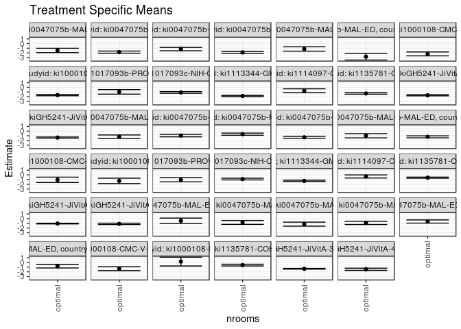

## Results Table

### Parameter: TSM

| agecat | studyid | country | intervention_level | baseline_level | estimate | ci_lower | ci_upper |
| --- | --- | --- | --- | --- | --- | --- | --- |
| Birth | ki0047075b-MAL-ED | BANGLADESH | optimal | observed | -0.4546408 | -1.0279131 | 0.1186314 |
| Birth | ki0047075b-MAL-ED | INDIA | optimal | observed | -0.8087133 | -1.2234865 | -0.3939401 |
| Birth | ki0047075b-MAL-ED | NEPAL | optimal | observed | -1.1738720 | -1.6011122 | -0.7466319 |
| Birth | ki0047075b-MAL-ED | PERU | optimal | observed | -0.9039163 | -1.2524841 | -0.5553486 |
| Birth | ki0047075b-MAL-ED | SOUTH AFRICA | optimal | observed | -0.6114383 | -0.9509183 | -0.2719582 |
| Birth | ki0047075b-MAL-ED | TANZANIA, UNITED REPUBLIC OF | optimal | observed | -0.7939349 | -1.1853948 | -0.4024750 |
| Birth | ki1000108-CMC-V-BCS-2002 | INDIA | optimal | observed | -1.3330467 | -1.7542088 | -0.9118846 |
| Birth | ki1000108-IRC | INDIA | optimal | observed | 0.1814598 | -0.7611208 | 1.1240404 |
| Birth | ki1135781-COHORTS | INDIA | optimal | observed | -0.5722825 | -0.7556903 | -0.3888747 |
| Birth | kiGH5241-JiVitA-3 | BANGLADESH | optimal | observed | -1.3561422 | -1.4247879 | -1.2874965 |
| Birth | kiGH5241-JiVitA-4 | BANGLADESH | optimal | observed | -1.4664710 | -1.6997208 | -1.2332213 |
| 6 months | ki0047075b-MAL-ED | BANGLADESH | optimal | observed | -1.1951167 | -1.5671146 | -0.8231188 |
| 6 months | ki0047075b-MAL-ED | INDIA | optimal | observed | -0.9548336 | -1.2208754 | -0.6887917 |
| 6 months | ki0047075b-MAL-ED | NEPAL | optimal | observed | -0.6531706 | -0.8782989 | -0.4280423 |
| 6 months | ki0047075b-MAL-ED | PERU | optimal | observed | -1.3228036 | -1.5233771 | -1.1222302 |
| 6 months | ki0047075b-MAL-ED | SOUTH AFRICA | optimal | observed | -0.9912835 | -1.4455585 | -0.5370085 |
| 6 months | ki0047075b-MAL-ED | TANZANIA, UNITED REPUBLIC OF | optimal | observed | -1.2224291 | -1.4396759 | -1.0051824 |
| 6 months | ki1000108-CMC-V-BCS-2002 | INDIA | optimal | observed | -1.0536415 | -1.6269847 | -0.4802983 |
| 6 months | ki1000108-IRC | INDIA | optimal | observed | -1.2820528 | -1.8548336 | -0.7092720 |
| 6 months | ki1017093b-PROVIDE | BANGLADESH | optimal | observed | -1.0399471 | -1.4874945 | -0.5923996 |
| 6 months | ki1017093c-NIH-Crypto | BANGLADESH | optimal | observed | -0.8928052 | -1.0767900 | -0.7088204 |
| 6 months | ki1113344-GMS-Nepal | NEPAL | optimal | observed | -1.2808614 | -1.4203016 | -1.1414212 |
| 6 months | ki1114097-CONTENT | PERU | optimal | observed | -0.3386938 | -0.6689451 | -0.0084424 |
| 6 months | ki1135781-COHORTS | INDIA | optimal | observed | -0.5917610 | -0.7087739 | -0.4747482 |
| 6 months | kiGH5241-JiVitA-3 | BANGLADESH | optimal | observed | -1.0469525 | -1.1233841 | -0.9705209 |
| 6 months | kiGH5241-JiVitA-4 | BANGLADESH | optimal | observed | -1.1083692 | -1.2527591 | -0.9639793 |
| 24 months | ki0047075b-MAL-ED | BANGLADESH | optimal | observed | -1.4675778 | -1.9324131 | -1.0027426 |
| 24 months | ki0047075b-MAL-ED | INDIA | optimal | observed | -1.8279893 | -2.0566798 | -1.5992988 |
| 24 months | ki0047075b-MAL-ED | NEPAL | optimal | observed | -1.1827302 | -1.5430552 | -0.8224052 |
| 24 months | ki0047075b-MAL-ED | PERU | optimal | observed | -1.8872515 | -2.0995284 | -1.6749745 |
| 24 months | ki0047075b-MAL-ED | SOUTH AFRICA | optimal | observed | -1.1531498 | -1.6226151 | -0.6836846 |
| 24 months | ki0047075b-MAL-ED | TANZANIA, UNITED REPUBLIC OF | optimal | observed | -2.8019321 | -3.5162671 | -2.0875972 |
| 24 months | ki1000108-CMC-V-BCS-2002 | INDIA | optimal | observed | -2.2097962 | -2.6257617 | -1.7938307 |
| 24 months | ki1000108-IRC | INDIA | optimal | observed | -1.6488274 | -1.7927964 | -1.5048584 |
| 24 months | ki1017093b-PROVIDE | BANGLADESH | optimal | observed | -0.9665204 | -1.4500255 | -0.4830153 |
| 24 months | ki1017093c-NIH-Crypto | BANGLADESH | optimal | observed | -1.0886802 | -1.2704000 | -0.9069603 |
| 24 months | ki1113344-GMS-Nepal | NEPAL | optimal | observed | -1.8504288 | -1.9779071 | -1.7229506 |
| 24 months | ki1114097-CONTENT | PERU | optimal | observed | -0.7336562 | -1.1588649 | -0.3084475 |
| 24 months | ki1135781-COHORTS | INDIA | optimal | observed | -1.2986670 | -1.4604459 | -1.1368880 |
| 24 months | kiGH5241-JiVitA-3 | BANGLADESH | optimal | observed | -1.7026883 | -1.8160916 | -1.5892850 |
| 24 months | kiGH5241-JiVitA-4 | BANGLADESH | optimal | observed | -1.3839900 | -1.5058335 | -1.2621465 |

### Parameter: E(Y)

| agecat | studyid | country | intervention_level | baseline_level | estimate | ci_lower | ci_upper |
| --- | --- | --- | --- | --- | --- | --- | --- |
| Birth | ki0047075b-MAL-ED | BANGLADESH | observed | observed | -1.0229487 | -1.1509575 | -0.8949400 |
| Birth | ki0047075b-MAL-ED | INDIA | observed | observed | -1.0069634 | -1.1525107 | -0.8614160 |
| Birth | ki0047075b-MAL-ED | NEPAL | observed | observed | -0.6998830 | -0.8579049 | -0.5418612 |
| Birth | ki0047075b-MAL-ED | PERU | observed | observed | -0.9447876 | -1.0604945 | -0.8290808 |
| Birth | ki0047075b-MAL-ED | SOUTH AFRICA | observed | observed | -0.6917890 | -0.8248091 | -0.5587689 |
| Birth | ki0047075b-MAL-ED | TANZANIA, UNITED REPUBLIC OF | observed | observed | -0.8810169 | -1.0869236 | -0.6751103 |
| Birth | ki1000108-CMC-V-BCS-2002 | INDIA | observed | observed | -0.9654444 | -1.1742112 | -0.7566777 |
| Birth | ki1000108-IRC | INDIA | observed | observed | -0.3079016 | -0.4694769 | -0.1463262 |
| Birth | ki1135781-COHORTS | INDIA | observed | observed | -0.6777626 | -0.7107167 | -0.6448086 |
| Birth | kiGH5241-JiVitA-3 | BANGLADESH | observed | observed | -1.5751978 | -1.5949779 | -1.5554177 |
| Birth | kiGH5241-JiVitA-4 | BANGLADESH | observed | observed | -1.4976642 | -1.5817349 | -1.4135935 |
| 6 months | ki0047075b-MAL-ED | BANGLADESH | observed | observed | -1.2033681 | -1.3212429 | -1.0854932 |
| 6 months | ki0047075b-MAL-ED | INDIA | observed | observed | -1.2159433 | -1.3345235 | -1.0973630 |
| 6 months | ki0047075b-MAL-ED | NEPAL | observed | observed | -0.5610593 | -0.6737915 | -0.4483272 |
| 6 months | ki0047075b-MAL-ED | PERU | observed | observed | -1.3280247 | -1.4371552 | -1.2188942 |
| 6 months | ki0047075b-MAL-ED | SOUTH AFRICA | observed | observed | -1.0548494 | -1.1845497 | -0.9251491 |
| 6 months | ki0047075b-MAL-ED | TANZANIA, UNITED REPUBLIC OF | observed | observed | -1.3601215 | -1.4821830 | -1.2380600 |
| 6 months | ki1000108-CMC-V-BCS-2002 | INDIA | observed | observed | -1.4234508 | -1.5645974 | -1.2823042 |
| 6 months | ki1000108-IRC | INDIA | observed | observed | -1.2470123 | -1.3779341 | -1.1160906 |
| 6 months | ki1017093b-PROVIDE | BANGLADESH | observed | observed | -1.0871041 | -1.1635539 | -1.0106543 |
| 6 months | ki1017093c-NIH-Crypto | BANGLADESH | observed | observed | -1.1986783 | -1.2700937 | -1.1272630 |
| 6 months | ki1113344-GMS-Nepal | NEPAL | observed | observed | -1.3321522 | -1.4103691 | -1.2539352 |
| 6 months | ki1114097-CONTENT | PERU | observed | observed | -0.3139217 | -0.4868486 | -0.1409948 |
| 6 months | ki1135781-COHORTS | INDIA | observed | observed | -1.0413281 | -1.0740395 | -1.0086167 |
| 6 months | kiGH5241-JiVitA-3 | BANGLADESH | observed | observed | -1.3132988 | -1.3364412 | -1.2901565 |
| 6 months | kiGH5241-JiVitA-4 | BANGLADESH | observed | observed | -1.3440477 | -1.3813060 | -1.3067894 |
| 24 months | ki0047075b-MAL-ED | BANGLADESH | observed | observed | -1.9431132 | -2.0691678 | -1.8170586 |
| 24 months | ki0047075b-MAL-ED | INDIA | observed | observed | -1.8458150 | -1.9718703 | -1.7197596 |
| 24 months | ki0047075b-MAL-ED | NEPAL | observed | observed | -1.2752193 | -1.3954783 | -1.1549603 |
| 24 months | ki0047075b-MAL-ED | PERU | observed | observed | -1.7500995 | -1.8705474 | -1.6296516 |
| 24 months | ki0047075b-MAL-ED | SOUTH AFRICA | observed | observed | -1.6228361 | -1.7581177 | -1.4875546 |
| 24 months | ki0047075b-MAL-ED | TANZANIA, UNITED REPUBLIC OF | observed | observed | -2.6058879 | -2.7403043 | -2.4714714 |
| 24 months | ki1000108-CMC-V-BCS-2002 | INDIA | observed | observed | -2.5593683 | -2.6601027 | -2.4586339 |
| 24 months | ki1000108-IRC | INDIA | observed | observed | -1.7853686 | -1.8795723 | -1.6911648 |
| 24 months | ki1017093b-PROVIDE | BANGLADESH | observed | observed | -1.5861179 | -1.6693668 | -1.5028689 |
| 24 months | ki1017093c-NIH-Crypto | BANGLADESH | observed | observed | -1.4295331 | -1.5127726 | -1.3462935 |
| 24 months | ki1113344-GMS-Nepal | NEPAL | observed | observed | -1.8835905 | -1.9681499 | -1.7990312 |
| 24 months | ki1114097-CONTENT | PERU | observed | observed | -0.6962195 | -0.8674103 | -0.5250287 |
| 24 months | ki1135781-COHORTS | INDIA | observed | observed | -2.0008909 | -2.0401990 | -1.9615828 |
| 24 months | kiGH5241-JiVitA-3 | BANGLADESH | observed | observed | -2.0127436 | -2.0404564 | -1.9850309 |
| 24 months | kiGH5241-JiVitA-4 | BANGLADESH | observed | observed | -1.7578934 | -1.7933205 | -1.7224663 |

### Parameter: PAR

| agecat | studyid | country | intervention_level | baseline_level | estimate | ci_lower | ci_upper |
| --- | --- | --- | --- | --- | --- | --- | --- |
| Birth | ki0047075b-MAL-ED | BANGLADESH | optimal | observed | -0.5683079 | -1.1246969 | -0.0119189 |
| Birth | ki0047075b-MAL-ED | INDIA | optimal | observed | -0.1982500 | -0.5907650 | 0.1942650 |
| Birth | ki0047075b-MAL-ED | NEPAL | optimal | observed | 0.4739890 | 0.0972316 | 0.8507464 |
| Birth | ki0047075b-MAL-ED | PERU | optimal | observed | -0.0408713 | -0.3502629 | 0.2685203 |
| Birth | ki0047075b-MAL-ED | SOUTH AFRICA | optimal | observed | -0.0803507 | -0.4142334 | 0.2535320 |
| Birth | ki0047075b-MAL-ED | TANZANIA, UNITED REPUBLIC OF | optimal | observed | -0.0870820 | -0.4238364 | 0.2496723 |
| Birth | ki1000108-CMC-V-BCS-2002 | INDIA | optimal | observed | 0.3676023 | -0.0274599 | 0.7626644 |
| Birth | ki1000108-IRC | INDIA | optimal | observed | -0.4893614 | -1.3989347 | 0.4202119 |
| Birth | ki1135781-COHORTS | INDIA | optimal | observed | -0.1054801 | -0.2853179 | 0.0743577 |
| Birth | kiGH5241-JiVitA-3 | BANGLADESH | optimal | observed | -0.2190556 | -0.2875917 | -0.1505196 |
| Birth | kiGH5241-JiVitA-4 | BANGLADESH | optimal | observed | -0.0311932 | -0.2540841 | 0.1916977 |
| 6 months | ki0047075b-MAL-ED | BANGLADESH | optimal | observed | -0.0082513 | -0.3788274 | 0.3623247 |
| 6 months | ki0047075b-MAL-ED | INDIA | optimal | observed | -0.2611097 | -0.5130470 | -0.0091724 |
| 6 months | ki0047075b-MAL-ED | NEPAL | optimal | observed | 0.0921113 | -0.1046325 | 0.2888551 |
| 6 months | ki0047075b-MAL-ED | PERU | optimal | observed | -0.0052211 | -0.1987807 | 0.1883386 |
| 6 months | ki0047075b-MAL-ED | SOUTH AFRICA | optimal | observed | -0.0635659 | -0.4950132 | 0.3678814 |
| 6 months | ki0047075b-MAL-ED | TANZANIA, UNITED REPUBLIC OF | optimal | observed | -0.1376923 | -0.3335980 | 0.0582134 |
| 6 months | ki1000108-CMC-V-BCS-2002 | INDIA | optimal | observed | -0.3698093 | -0.9247942 | 0.1851756 |
| 6 months | ki1000108-IRC | INDIA | optimal | observed | 0.0350404 | -0.5111257 | 0.5812065 |
| 6 months | ki1017093b-PROVIDE | BANGLADESH | optimal | observed | -0.0471570 | -0.4858729 | 0.3915589 |
| 6 months | ki1017093c-NIH-Crypto | BANGLADESH | optimal | observed | -0.3058731 | -0.4779904 | -0.1337559 |
| 6 months | ki1113344-GMS-Nepal | NEPAL | optimal | observed | -0.0512908 | -0.1729106 | 0.0703290 |
| 6 months | ki1114097-CONTENT | PERU | optimal | observed | 0.0247721 | -0.2711155 | 0.3206597 |
| 6 months | ki1135781-COHORTS | INDIA | optimal | observed | -0.4495670 | -0.5672624 | -0.3318717 |
| 6 months | kiGH5241-JiVitA-3 | BANGLADESH | optimal | observed | -0.2663463 | -0.3428189 | -0.1898737 |
| 6 months | kiGH5241-JiVitA-4 | BANGLADESH | optimal | observed | -0.2356785 | -0.3757875 | -0.0955694 |
| 24 months | ki0047075b-MAL-ED | BANGLADESH | optimal | observed | -0.4755354 | -0.9354784 | -0.0155924 |
| 24 months | ki0047075b-MAL-ED | INDIA | optimal | observed | -0.0178257 | -0.1995901 | 0.1639388 |
| 24 months | ki0047075b-MAL-ED | NEPAL | optimal | observed | -0.0924891 | -0.4237664 | 0.2387882 |
| 24 months | ki0047075b-MAL-ED | PERU | optimal | observed | 0.1371520 | -0.0491134 | 0.3234174 |
| 24 months | ki0047075b-MAL-ED | SOUTH AFRICA | optimal | observed | -0.4696863 | -0.9217339 | -0.0176387 |
| 24 months | ki0047075b-MAL-ED | TANZANIA, UNITED REPUBLIC OF | optimal | observed | 0.1960443 | -0.4896686 | 0.8817572 |
| 24 months | ki1000108-CMC-V-BCS-2002 | INDIA | optimal | observed | -0.3495721 | -0.7639845 | 0.0648403 |
| 24 months | ki1000108-IRC | INDIA | optimal | observed | -0.1365411 | -0.2480249 | -0.0250573 |
| 24 months | ki1017093b-PROVIDE | BANGLADESH | optimal | observed | -0.6195974 | -1.0928766 | -0.1463183 |
| 24 months | ki1017093c-NIH-Crypto | BANGLADESH | optimal | observed | -0.3408529 | -0.5150973 | -0.1666085 |
| 24 months | ki1113344-GMS-Nepal | NEPAL | optimal | observed | -0.0331617 | -0.1327860 | 0.0664627 |
| 24 months | ki1114097-CONTENT | PERU | optimal | observed | 0.0374367 | -0.3145781 | 0.3894515 |
| 24 months | ki1135781-COHORTS | INDIA | optimal | observed | -0.7022240 | -0.8627519 | -0.5416960 |
| 24 months | kiGH5241-JiVitA-3 | BANGLADESH | optimal | observed | -0.3100553 | -0.4196894 | -0.2004212 |
| 24 months | kiGH5241-JiVitA-4 | BANGLADESH | optimal | observed | -0.3739034 | -0.4907979 | -0.2570089 |